# **Prosper Loan Data Exploration by Adam McDonald**

# Overview of Dataset

The dataset includes 113,937 loans with 81 variables.

```
## [1] 113937     81
```

The variables are:

```
##  [1] "ListingKey"
##  [2] "ListingNumber"
##  [3] "ListingCreationDate"
##  [4] "CreditGrade"
##  [5] "Term"
##  [6] "LoanStatus"
##  [7] "ClosedDate"
##  [8] "BorrowerAPR"
##  [9] "BorrowerRate"
## [10] "LenderYield"
## [11] "EstimatedEffectiveYield"
## [12] "EstimatedLoss"
## [13] "EstimatedReturn"
## [14] "ProsperRating..numeric."
## [15] "ProsperRating..Alpha."
```

[output cut: 66 more lines]

I will limit the data to only the below 10 variables that I would like to explore further.

```
##  [1] "LoanStatus"              "BorrowerAPR"
##  [3] "EstimatedReturn"         "ProsperRating..numeric."
##  [5] "EmploymentStatus"        "CreditScoreRangeLower"
##  [7] "DebtToIncomeRatio"       "IncomeRange"
##  [9] "LoanOriginationDate"     "MonthlyLoanPayment"
```

```
##                  LoanStatus     BorrowerAPR      EstimatedReturn
##  Current              :56576   Min.   :0.00653   Min.   :-0.183
##  Completed            :38074   1st Qu.:0.15629   1st Qu.: 0.074
##  Chargedoff           :11992   Median :0.20976   Median : 0.092
##  Defaulted            : 5018   Mean   :0.21883   Mean   : 0.096
##  Past Due (1-15 days) :  806   3rd Qu.:0.28381   3rd Qu.: 0.117
##  Past Due (31-60 days):  363   Max.   :0.51229   Max.   : 0.284
##  (Other)              : 1108   NA's   :25        NA's   :29084
##  ProsperRating..numeric.      EmploymentStatus CreditScoreRangeLower
##  Min.   :1.000           Employed     :67322   Min.   :  0.0
##  1st Qu.:3.000           Full-time    :26355   1st Qu.:660.0
##  Median :4.000           Self-employed: 6134   Median :680.0
##  Mean   :4.072           Not available: 5347   Mean   :685.6
##  3rd Qu.:5.000           Other        : 3806   3rd Qu.:720.0
##  Max.   :7.000                        : 2255   Max.   :880.0
##  NA's   :29084           (Other)      : 2718   NA's   :591
##  DebtToIncomeRatio         IncomeRange             LoanOriginationDate
##  Min.   : 0.000    $25,000-49,999:32192   2014-01-22 00:00:00:   491
##  1st Qu.: 0.140    $50,000-74,999:31050   2013-11-13 00:00:00:   490
##  Median : 0.220    $100,000+     :17337   2014-02-19 00:00:00:   439
##  Mean   : 0.276    $75,000-99,999:16916   2013-10-16 00:00:00:   434
##  3rd Qu.: 0.320    Not displayed : 7741   2014-01-28 00:00:00:   339
##  Max.   :10.010    $1-24,999     : 7274   2013-09-24 00:00:00:   316
##  NA's   :8554      (Other)       : 1427   (Other)            :111428
##  MonthlyLoanPayment
##  Min.   :   0.0
##  1st Qu.: 131.6
##  Median : 217.7
##  Mean   : 272.5
##  3rd Qu.: 371.6
##  Max.   :2251.5
##
```

# Univariate Plots Section

First I will look at variables related to the loans:

### Loan Origination Date

```
##         Min.      1st Qu.       Median         Mean      3rd Qu.
## "2005-11-15" "2008-10-02" "2012-06-26" "2011-07-21" "2013-09-18"
##         Max.
## "2014-03-12"
```

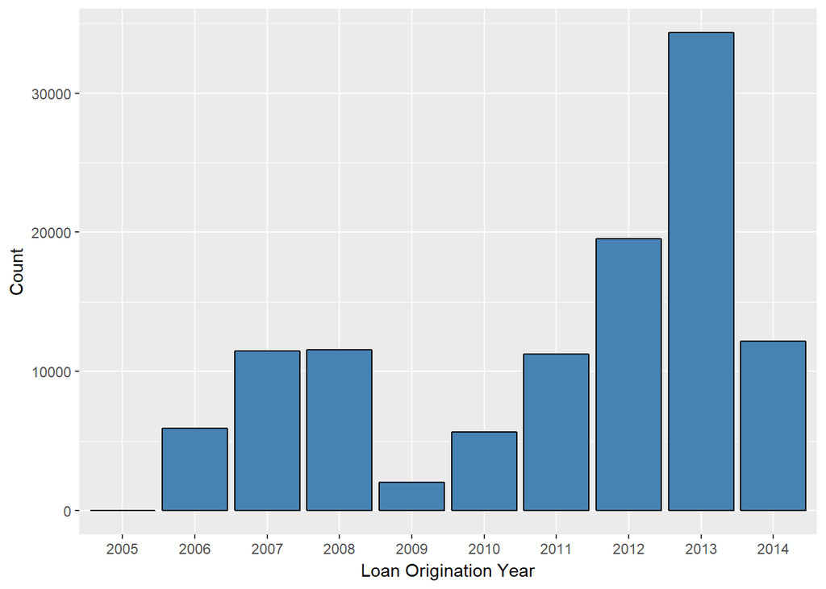

The data includes loans from November 2005 through March 2014. There was a low point during the financial crisis in 2009, but we see solid growth in the number of loans each year from there.

### Loan Status

```
##              Cancelled             Chargedoff              Completed
##                      5                  11992                  38074
##                Current              Defaulted FinalPaymentInProgress
##                  56576                   5018                    205
##   Past Due (>120 days)   Past Due (1-15 days)  Past Due (16-30 days)
##                     16                    806                    265
##  Past Due (31-60 days)  Past Due (61-90 days) Past Due (91-120 days)
##                    363                    313                    304
```

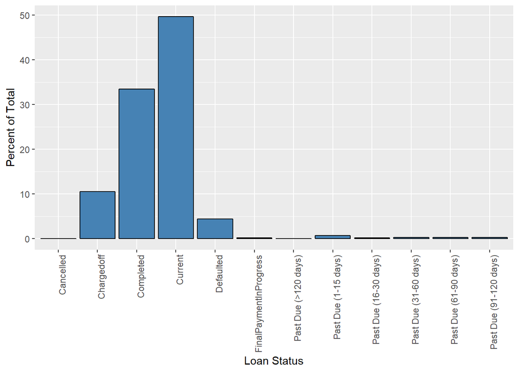

About 15% of loans fall into either Charged Off or Defaulted, while just under 85% or Completed or Current. The remaining items are small amounts of the total number of loans. I will convert the Loan Status into a column that is either Performing or Non-Performing. The performing will be either completed or current and the non-perfomring will be anything else.

### Loan Status

```
##    Length     Class      Mode
##    113937 character character
```

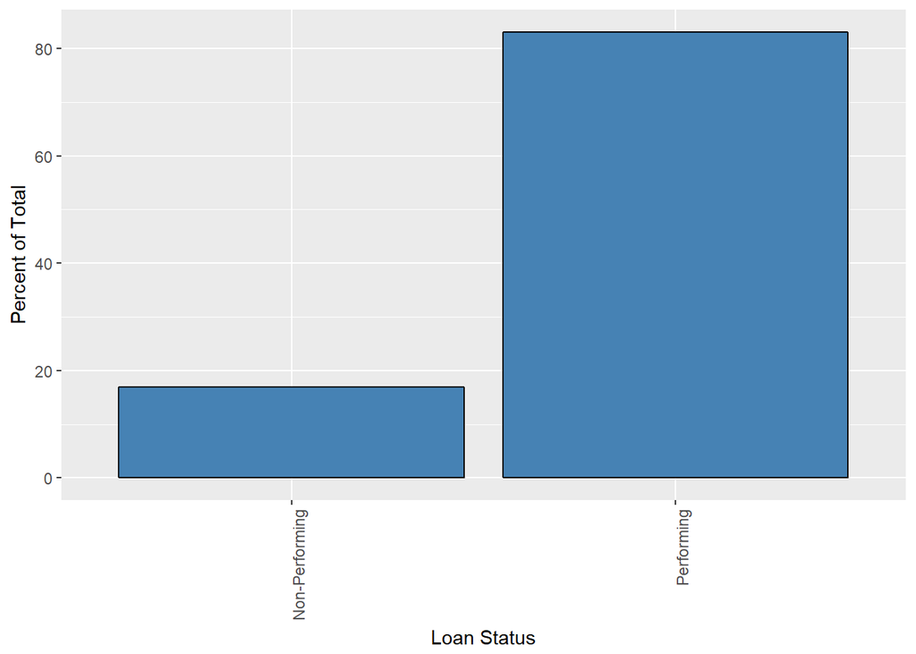

### Monthly Loan Payment

```
##    Min. 1st Qu.  Median    Mean 3rd Qu.    Max.
##     0.0   131.6   217.7   272.5   371.6  2251.5
```

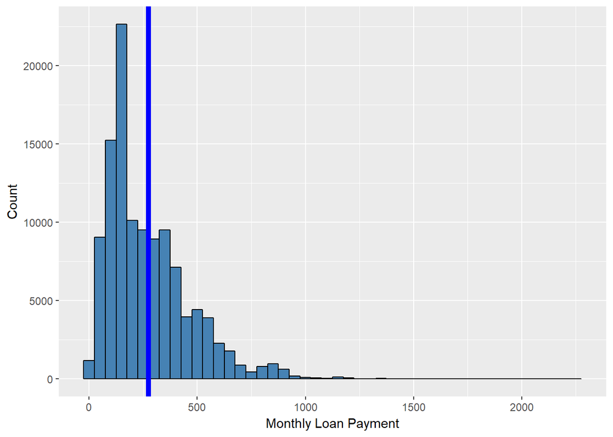

This is right skewed with the average amount aroud $270 per month and the median around $217 per month. Most loans have a pretty small monthly payment amount.

Now I will shift to variables that are related to the borrower:

### Employment Status

```
##                    Employed     Full-time Not available  Not employed
##          2255         67322         26355          5347           835
##         Other     Part-time       Retired Self-employed
##          3806          1088           795          6134
```

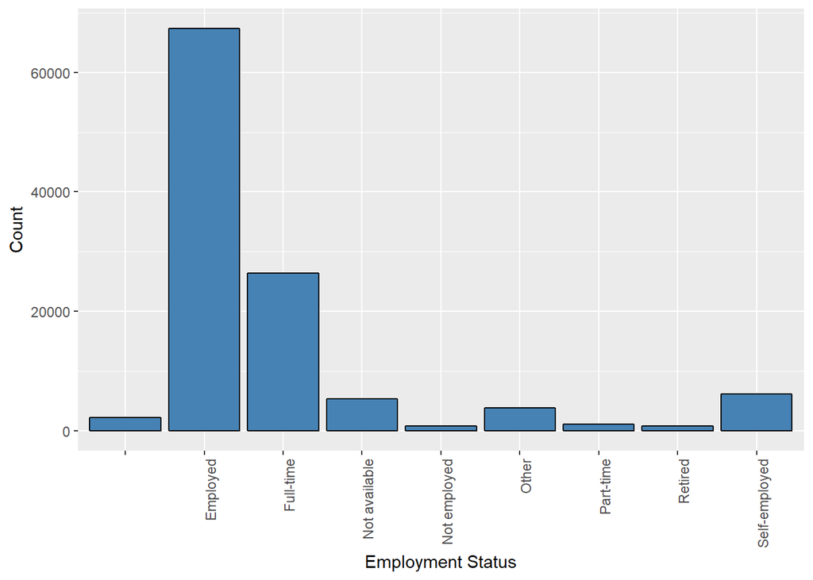

Borrowers are mostly employed, but there is a small amount not employed or retired.

### Income Range

```
##             $0      $1-24,999      $100,000+ $25,000-49,999 $50,000-74,999
##            621           7274          17337          32192          31050
## $75,000-99,999  Not displayed   Not employed
##          16916           7741            806
```

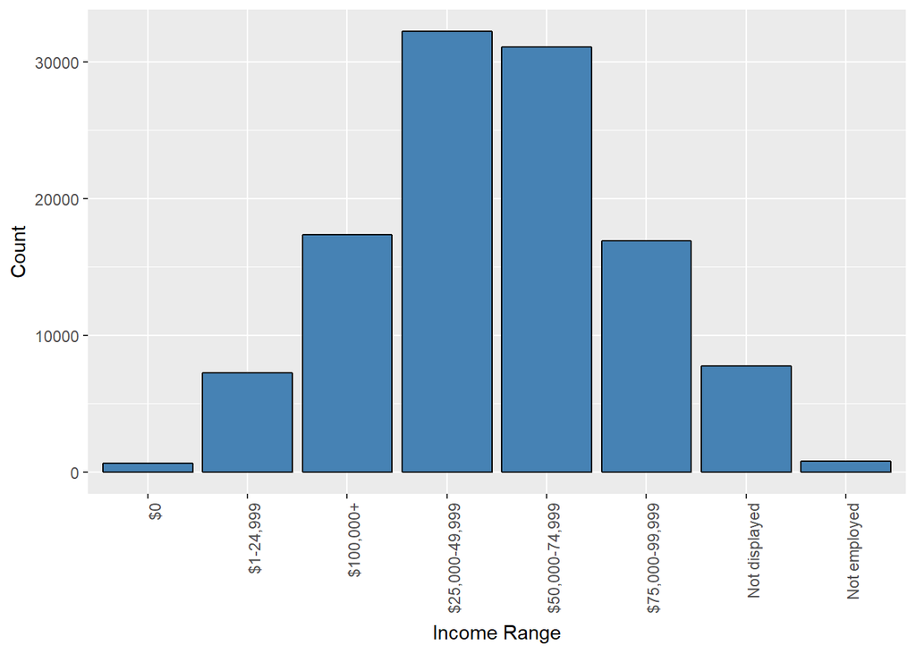

Looks like the factors are out of order for the Income Range, I will adjust this and redisplay the graph.

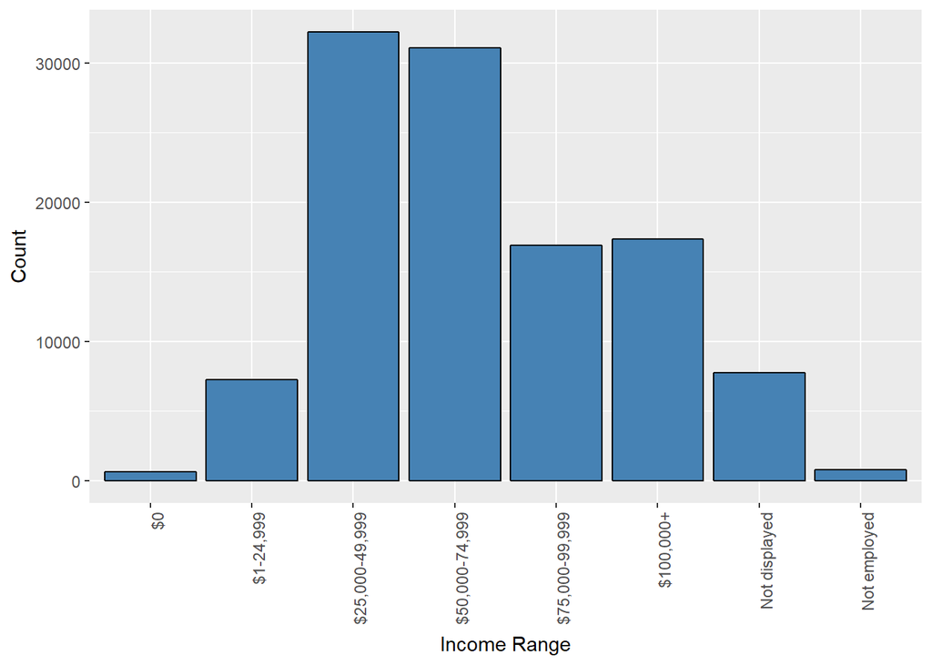

The income range isn’t quite normally distributed. It appears a little off, with $100,000 being somewhat high. This could be because the income range is self reported or it could just be higher income people are using more loans.

### Debt to Income Ratio

```
##    Min. 1st Qu.  Median    Mean 3rd Qu.    Max.    NA's
##   0.000   0.140   0.220   0.276   0.320  10.010    8554
```

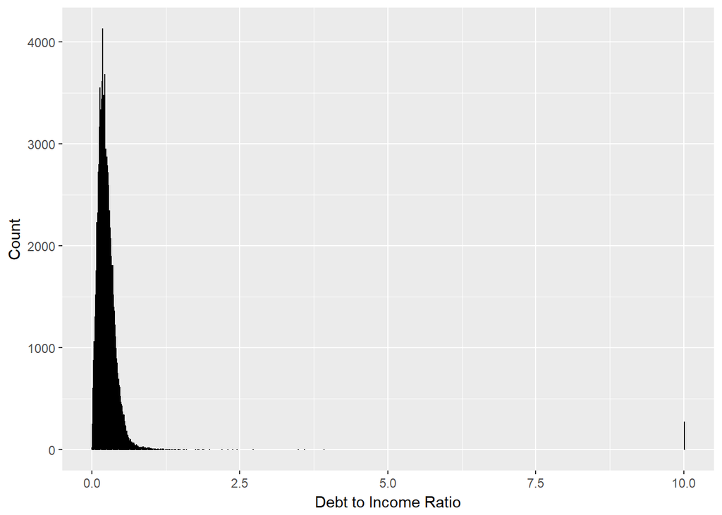

This is skewed by outliers, and tough to see the distribution. I am going to exclude the top 1% from the graph.

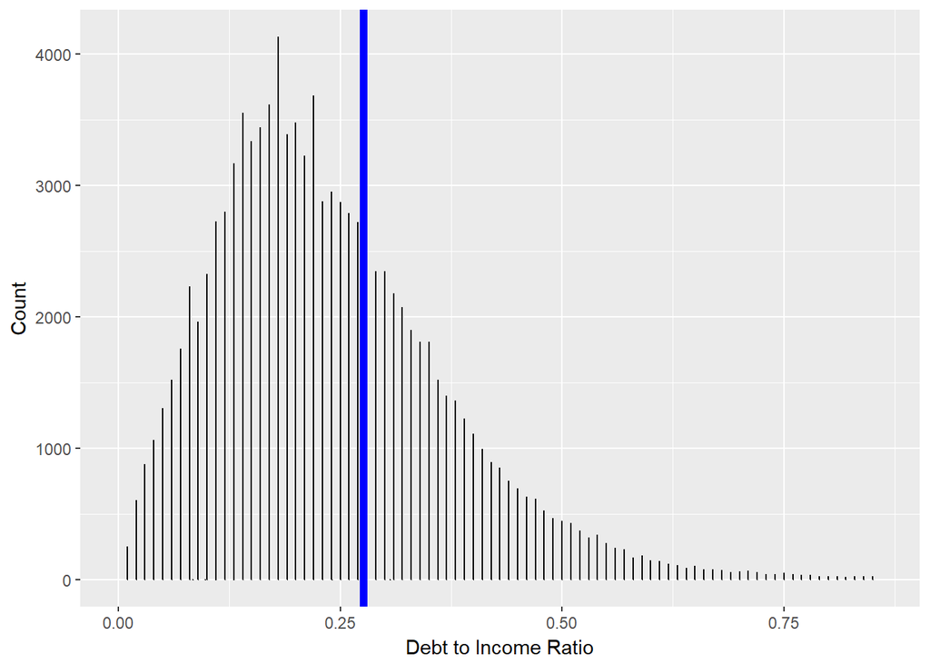

The distribution is slightly right skewed, The mean is 0.276, while the median is only 0.22.

### Credit Score

```
##    Min. 1st Qu.  Median    Mean 3rd Qu.    Max.    NA's
##     0.0   660.0   680.0   685.6   720.0   880.0     591
```

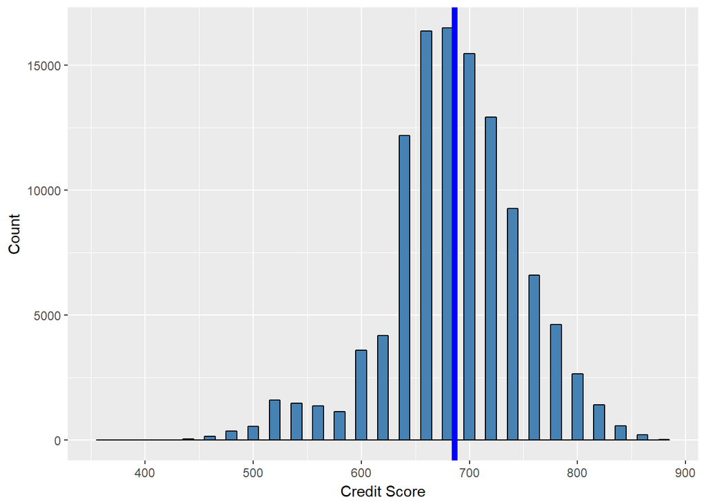

The distribution of credit scores is centered at a median of 680 and a mean or 686. It is barely skewed left with lower credit scores most likely not being approved as frequently.

### Prosper Rating

```
##    Min. 1st Qu.  Median    Mean 3rd Qu.    Max.    NA's
##   1.000   3.000   4.000   4.072   5.000   7.000   29084
```

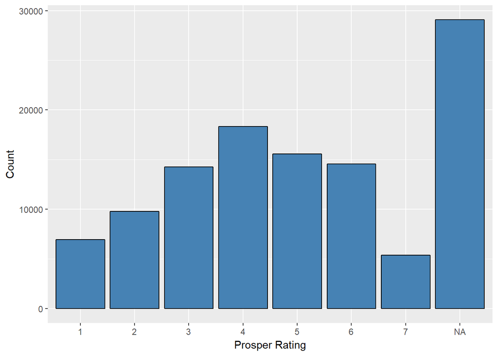

The Prosper Rating distribution is relatively normal. This makes sense as they are rating the risk of loans. They don’t necessarily want too many highly rated loans because those don’t provide much of a return, but the higher return on riskier loans doesn’t necessarily outwiegh the risk of default.

### Borrower APR

```
##    Min. 1st Qu.  Median    Mean 3rd Qu.    Max.    NA's
## 0.00653 0.15629 0.20976 0.21883 0.28381 0.51229      25
```

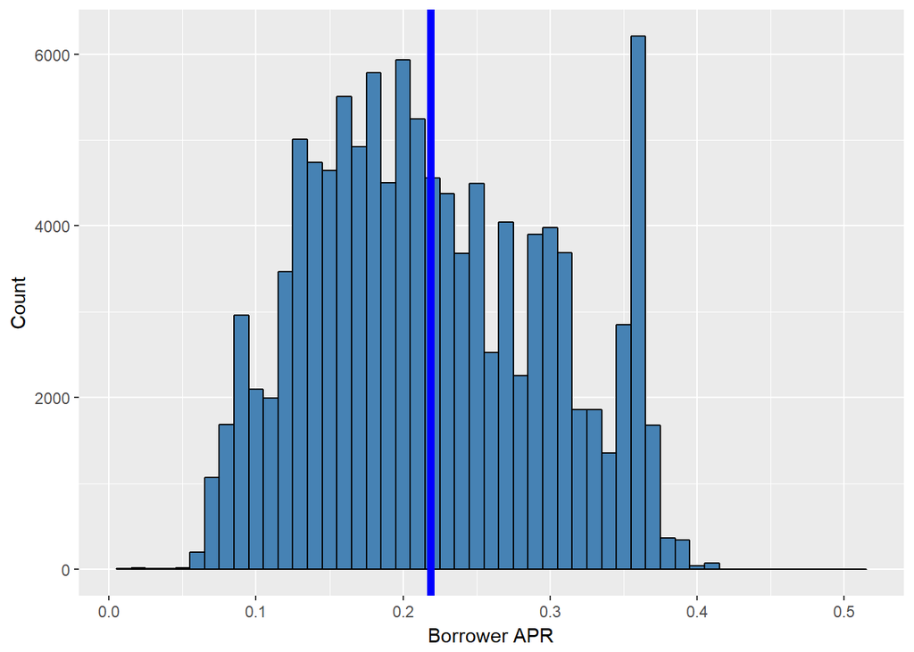

### Estimated Return

```
##    Min. 1st Qu.  Median    Mean 3rd Qu.    Max.    NA's
##  -0.183   0.074   0.092   0.096   0.117   0.284   29084
```

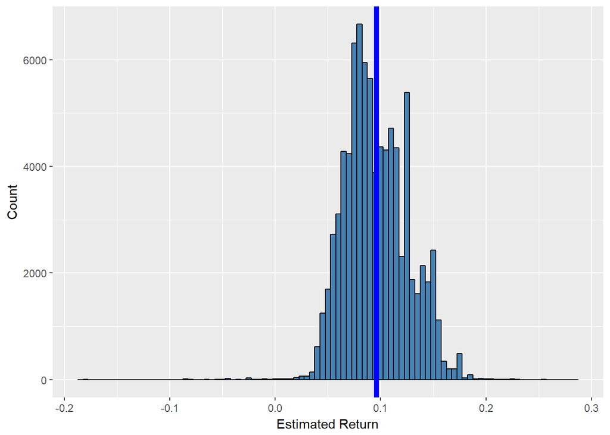

The estimated return follows a similar distribution as the APR, which makes sense because the interest rate is set to give a return based on the amount of risk involved in the loan.

# Univariate Analysis

### What is/are the main feature(s) of interest in your dataset?

I am most interested in the interest rate for the loans. I am interested to see what impacts the interest rates the most and how it relates to the estimated return.

### What other features in the dataset do you think will help support your investigation into your feature(s) of interest?

I am interested in seeing if the Loan Status can be predicted by any certain variable. For example, do lower Prosper Ratings lead to higher non-performance rates? I am also interested to see which variables influence interest rates the most.

### Did you perform any operations on the data to tidy, adjust, or change the form of the data? If so, why did you do this?

I changed the order of factors in Income Range so that they showed in order when creating the histogram. I also changed Loan Origination Date to a date format instead of a factor. Finally, I changed the Loan Status to be either performing or non-performing to make looking at the status a little easier.

# Bivariate Plots Section

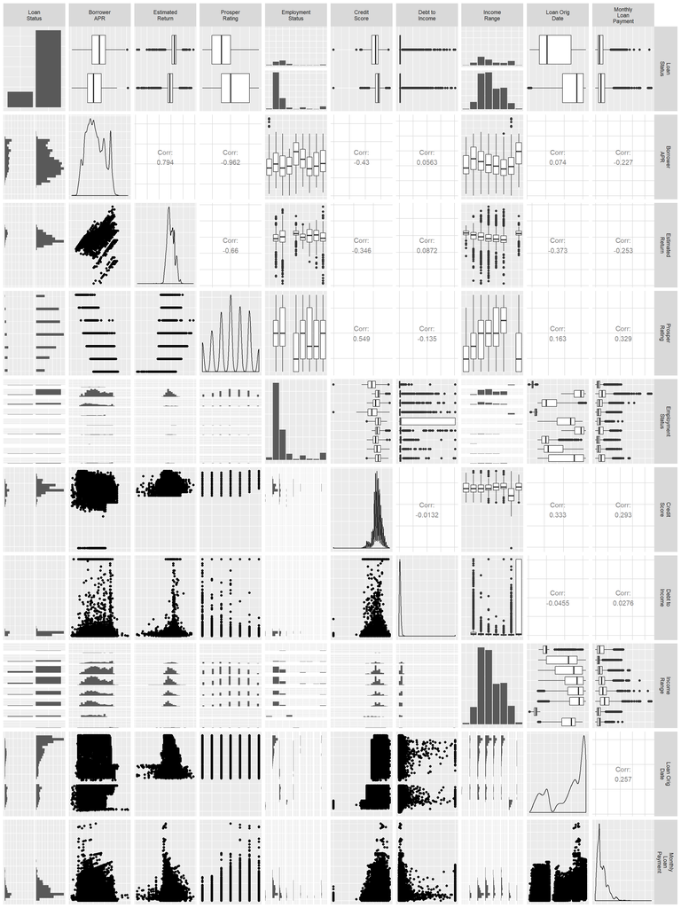

The highest correlation appears to be between the Prosper Rating and the Borrower APR. Next is the Estimated Return and Interest Rate followed by the Estimated Return and Prosper Rating. This makes sense, the Interest Rate is based off the Prosper Rating and the Estimated Return is mostly based off the Prosper Rating, but also from the size and length of the loan.

I will begin by looking at the Loan Status and different variables.

### Prosper Rating by Loan Status

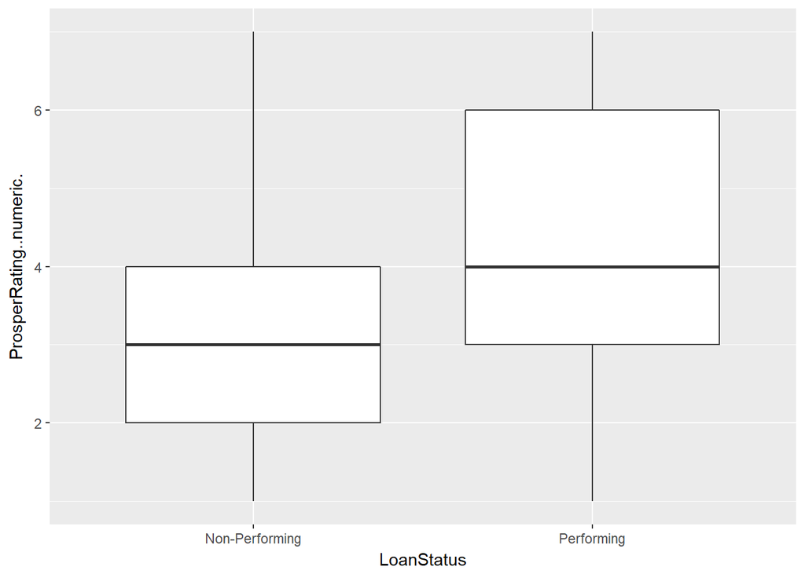

Here we see that the higher the Prosper Rating the more likely the loan is to be performing. It seems that the Prosper Rating is pretty good at predicting how risky the loan is. The median for Non-Performing loans is 3 and the median of performing loans is 4.

### Credit Score by Loan Status

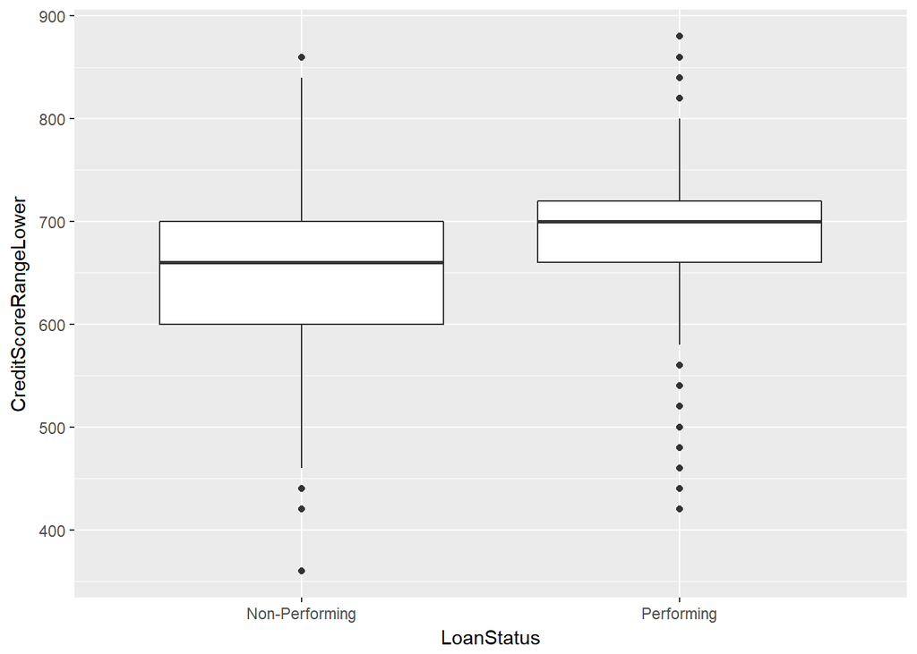

### Income Range by Loan Status

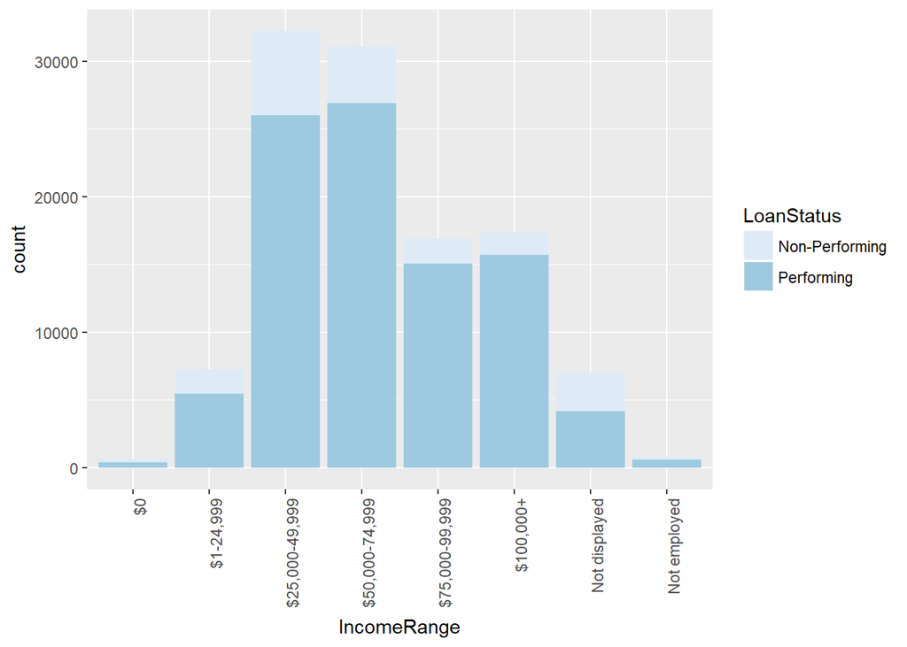

### Loan Origination Date by Loan Status

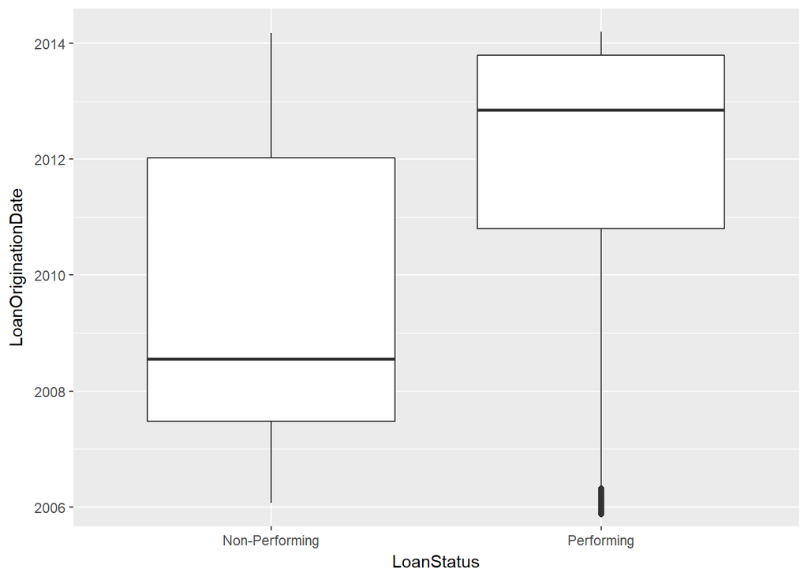

Over time a greater amount of loans have completed or are current. It would be interesting to see if that is because people taking loans have better credit scores some other factor. The median of Non-Performing loans is late 2008, while the median of Performing loans is late 2012.

Now I will take a look at the relationship of Borrower APR with different variables.

### Prosper Rating by Borrower APR

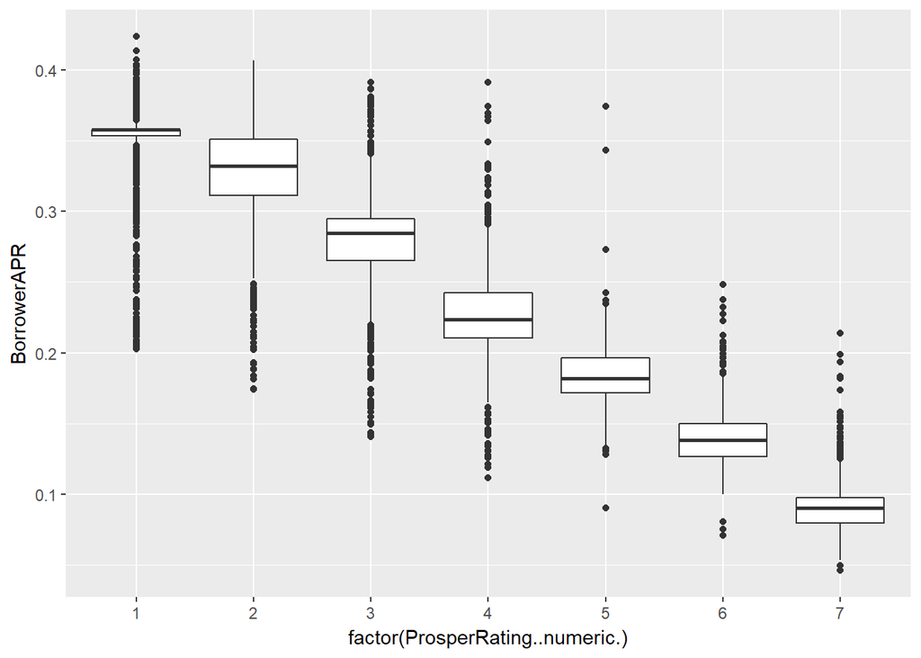

As the Prosper Rating increases the Borrower APR charged goes down, which makes sense because the less risky the loan the less interest borrowers have to pay. The boxplots show that the median APR goes down with each increase to the prosper rating. As we saw above the correlation is -0.962 between these 2 variables. It also looks like the variances of rates goes down as the Prosper Rating increases. This may be because any Prosper Rating lower than 4 takes more factors into account when choosing an interest rate.

### Estimated Return by Borrower APR

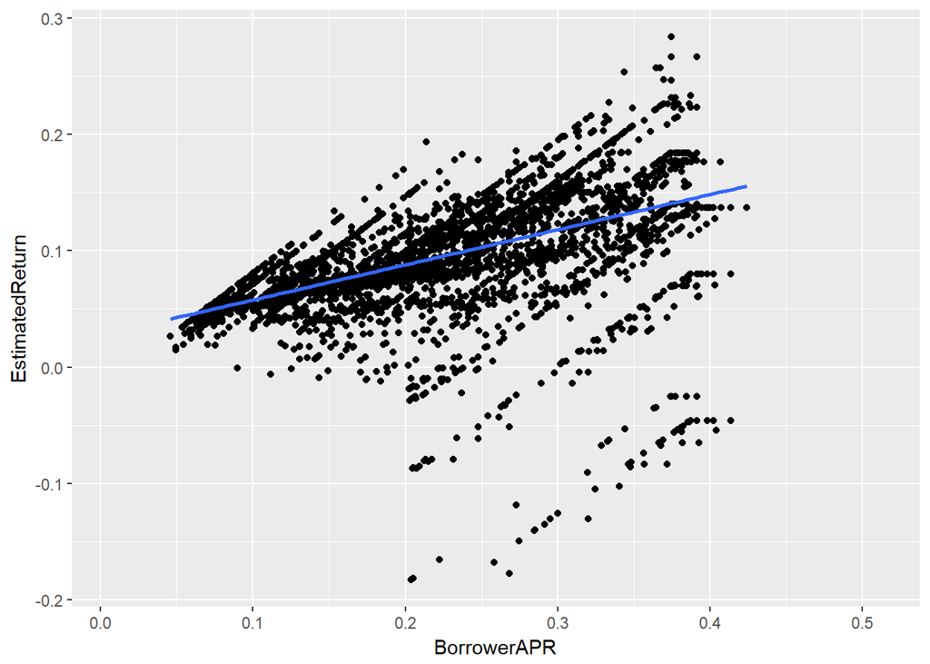

The Estimated Return and Borrower APR are positively correlated at 0.794. There is definitely a relationship that as the rate increases the return does as well. There is another factor here that is causing the estimated return to shift up or down, we will explore this further in the Multivarate Analysis.

### Prosper Rating by Estimated Return

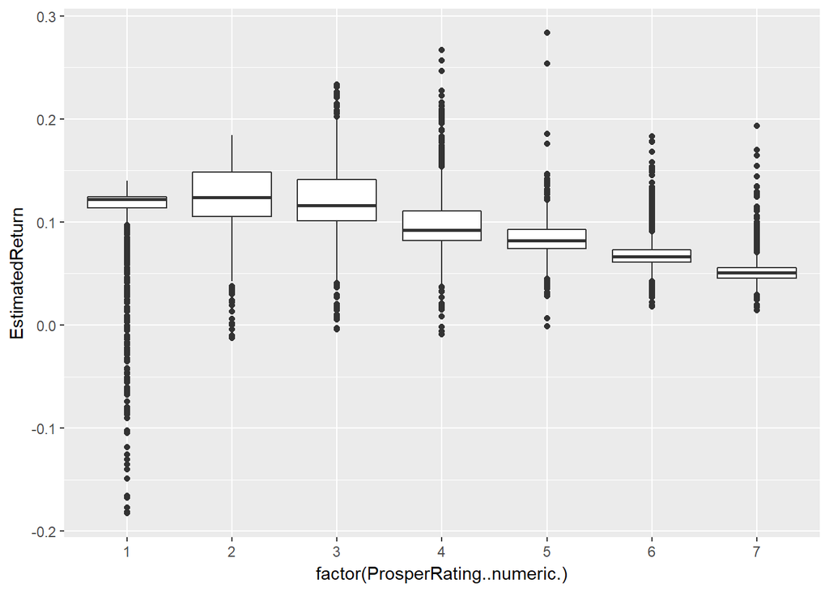

# Bivariate Analysis

### Talk about some of the relationships you observed in this part of the investigation. How did the feature(s) of interest vary with other features in the dataset?

First I looked at the relationship between Loan Status and a few other variables. It appears that the Prosper Rating does show an ability to predict if a loan will complete or not. Some of the factors that go into the Prosper Rating like the Credit Score and Income Range by themselves aren’t a good indicator as to whether a loan will complete or not. I also looked at the relationships between Borrower APR, Estimated Return, and Prosper Rating. These are all pretty strongly correlated and have the closest relationships of any variables in the dataset.

# Multivariate Plots Section

### Estimated Return by Borrower APR and Prosper Rating

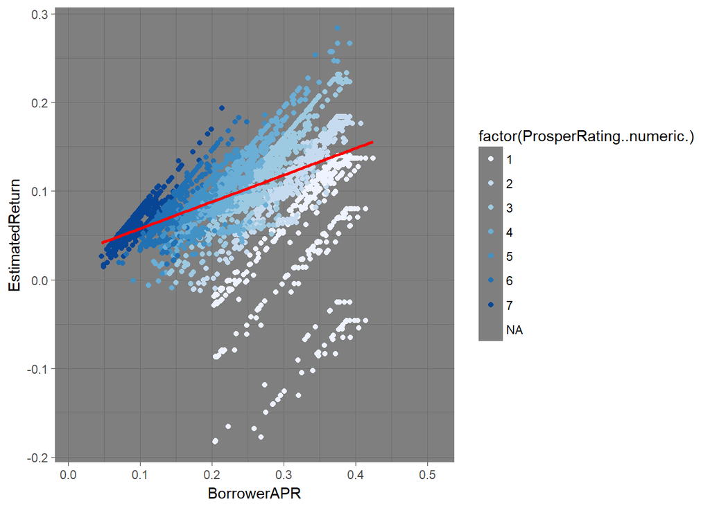

Here I look again at Estimated Return by Borrower APR, but add in a color for the Propser Rating. This helps explains the banding that occurs. Yes the Estimated Return does go up as the APR increases, but the line is shifted up or down based on the Prosper Rating. The higher the Prosper Rating the higher the floor of the Estimated Return is.

### Estimated Return by Borrower APR and Loan Origination Date

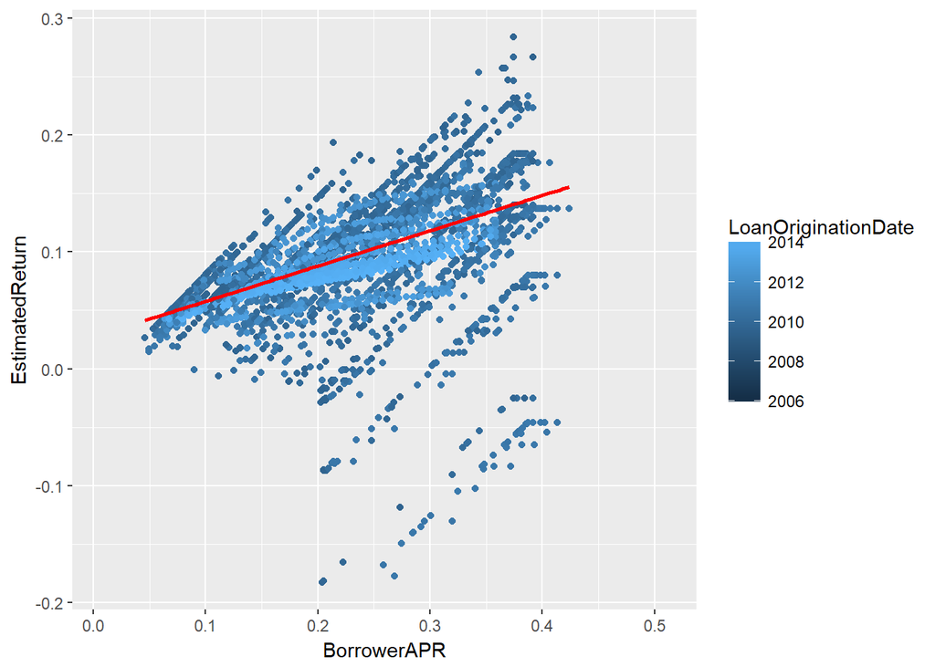

This is pretty interesting. It looks like the slope of the Estimated Return vs Borrower APR has gotten lower over time. For more recent loans the increase in the interest rate doesn’t increase the estimated return as much as it used to.

### Prosper Rating by Loan Status and Borrower APR

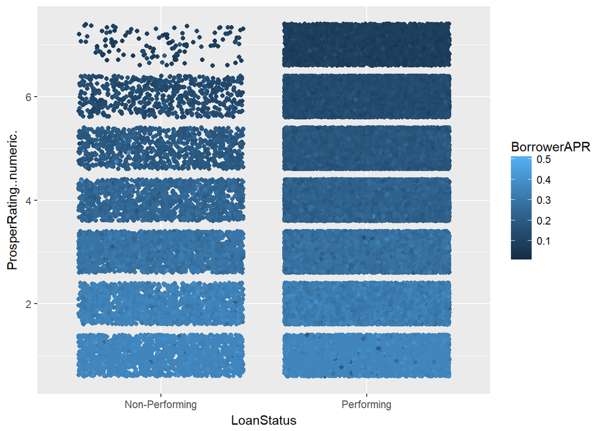

This plot shows that the higher the Prosper Rating the lower the percentage of Non-Performing loans and the lower the APR. What is somewhat interesting is there are some low Prosper Rating that have a higher APR, but are still current or completed. Looking it appears there are more of those loans in the Performing status.

# Multivariate Analysis

### Talk about some of the relationships you observed in this part of the investigation. Were there features that strengthened each other in terms of looking at your feature(s) of interest?

The Estimated Return, Prosper Rating, and Borrower APR are all three closely related. There is a strong positive linear relationship between the interest rate and the return. This linear relationship is shifted up or down based on the Prosper Rating.

### Were there any interesting or surprising interactions between features?

I was surprised that the slope of the Estimated Return vs Borrower APR has gotten lower over time. It seems that they have made some changes to make the estimated return less variable regardless of the interest rates.

# Final Plots and Summary

### Plot One

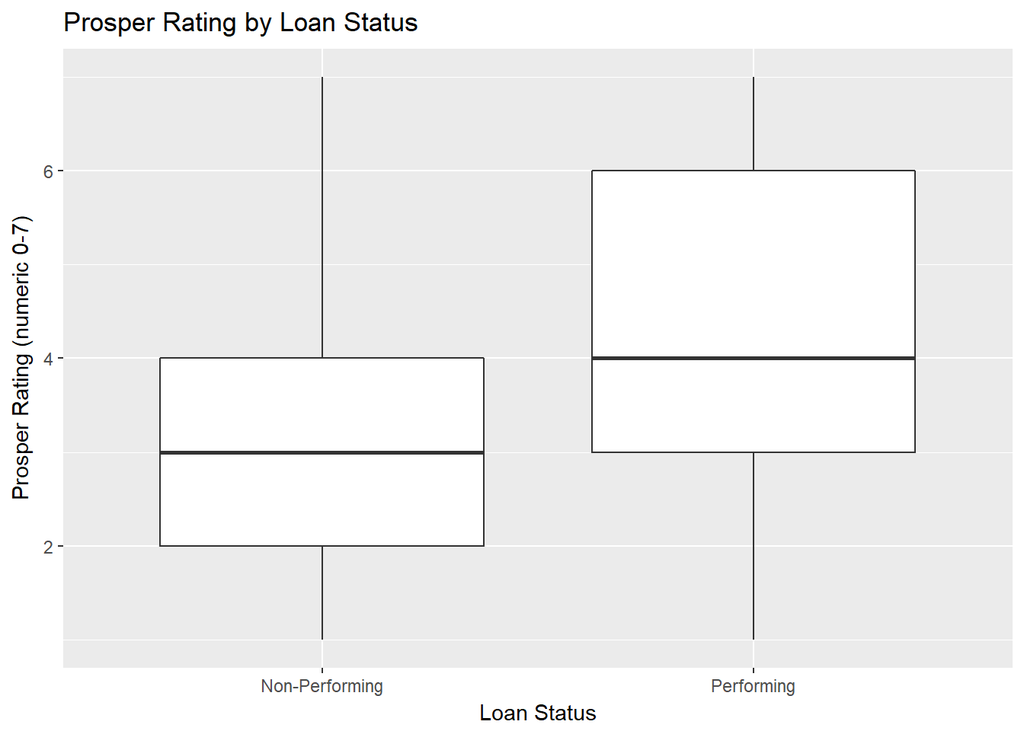

### Description One

I like this simple boxplot because it clearly shows that the Prosper Rating historically has done a good job of rating the riskiness of a loan. Non-Performing loans have had lower Prosper Ratings assigned at the origination of the loan.

### Plot Two

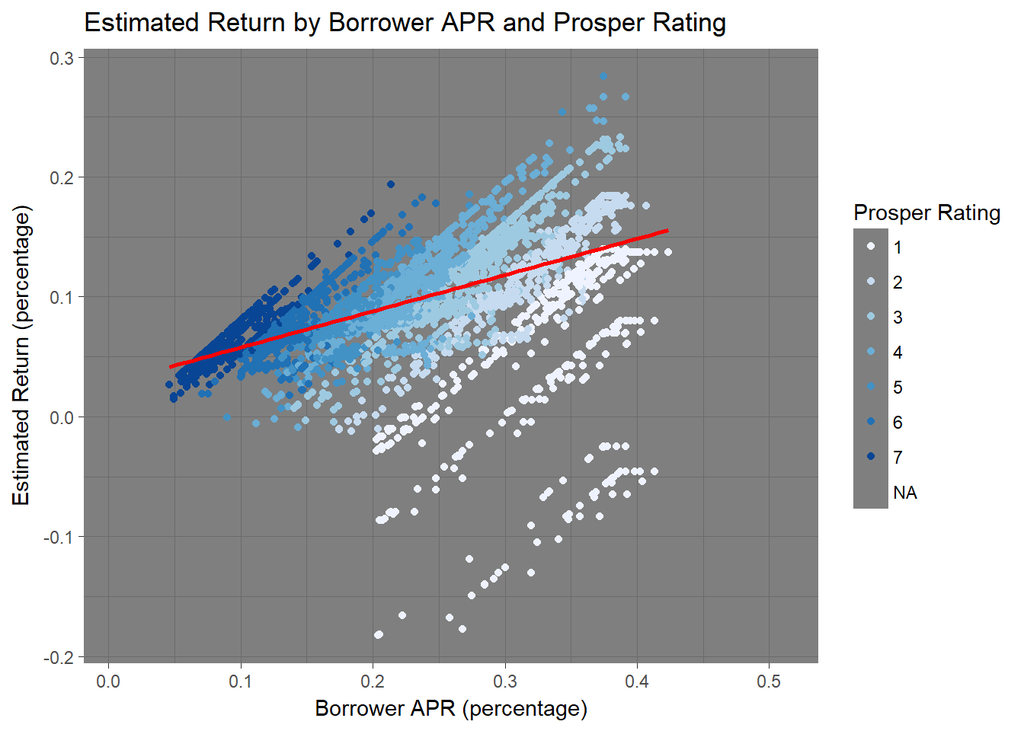

### Description Two

This plot does a good job of illustrating the relationship between Estimated Return, Borrower APR, and Prosper Rating. There is a strong positive linear relationship between the interest rate and the return. This linear relationship is shifted up or down based on the Prosper Rating. Including both APR and Prosper Rating in a model could probably predict Estimated Return pretty well.

### Plot Three

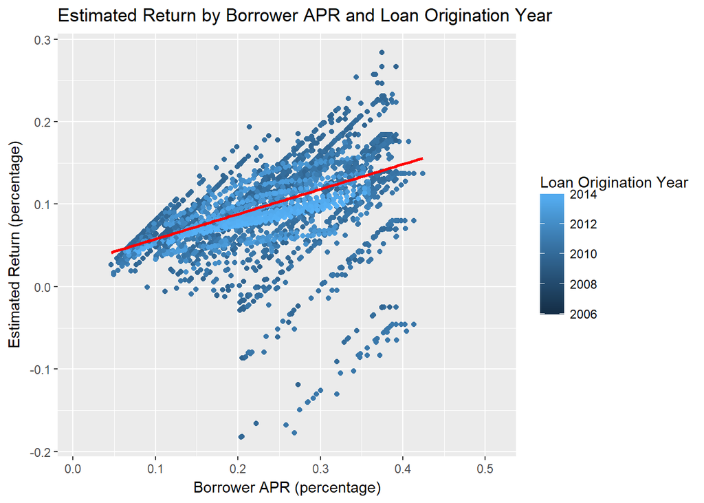

### Description Three

This plot is similar to the second plot, but changes out the Prosper Rating for the Loan Origination Year. It again shows the relationship between Estimated Return and Borrower APR, but shows how it is changing over time. In later years the slope of the line decreases, meaning an increase in APR in 2014 increases the Estimated Return less than it it did in 2006.

# Reflection

Using the Prosper loan data set, I selected 10 of the 81 variables to explore further. I wanted to investigate the Loan Status and adjusted the variable to be Performing or Non-Performing to find how many loans completed or are current versus the other categories. I wanted to look and see which factors led to a loan not completing. I also looked at the Borrower APR, Estimated Return, and Prosper Score. I wanted to see the relationship between the 3.

One of the difficuties was trying to choose which variables to look at. With 81 different variables it was necessary to narrow down my exploration. It would be interesting to go back and look at other variables in the data set knowing what I do about the 10 I chose.

For future Analysis I think it would be interesting to create a model that usese variables to predict the Prosper Rating. I would then change the model and see if I could create a rating that is even better predicting how a loan will perform.